# Reproducible Research: Assignment 1

1. Load the data (i.e. 𝚛𝚎𝚊𝚍.𝚌𝚜𝚟())

```r
filepath <- "~/Desktop/activity.csv"
library(readr)
#read data frame
activity <- read_csv(filepath,
    col_types = cols(steps = col_integer()))
```

2. Process/transform the data (if necessary) into a format suitable for your analysis

```r
#convert column with dates into R native date format
activity$date <- as.Date(activity$date, format = "%Y-%m-%d")
#create a weekday variable
activity$weekday <- weekdays(activity$date)
#out of weekday, create a weekend dummy
activity$weekend <- activity$weekday %in% c("Saturday", "Sunday")
```

### What is mean total number of steps taken per day?

1. Calculate the total number of steps taken per day

```r
activityByDateMean <- aggregate(steps~date,activity, sum)
```

```r
library(ggplot2)
ggplot(activityByDateMean, aes(steps)) + geom_histogram(bins = 45, alpha = 0.6, fill = "blue") + geom_density()

ggsave(filename="Histogram.png")
```

[output not shown]

```r
activityByDateSum <- aggregate(steps ~ interval, data=activity, sum)
summary(activityByDateSum$steps)
```

```
   Min. 1st Qu.  Median    Mean 3rd Qu.    Max.
    0.0   131.8  1808.0  1981.0  2800.0 10930.0
```

### What is the average daily activity pattern

1. Make a time series plot (i.e. 𝚝𝚢𝚙𝚎 = “𝚕”) of the 5-minute interval (x-axis) and the average number of steps taken, averaged across all days (y-axis)

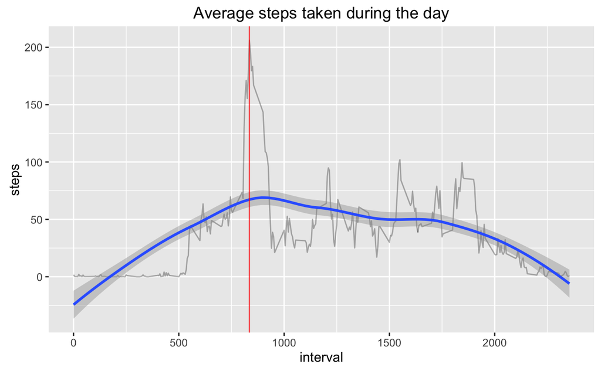

```r
activityByIntervalSum <- aggregate(steps~interval,activity, mean)
ggplot(activityByIntervalSum, aes(x = interval, y = steps)) + geom_line(alpha = 0.3) + geom_smooth() +ggtitle(label = "Average steps taken during the day") + geom_vline(xintercept = activity[which.max(activityByIntervalSum$steps),]$interval, col = "red", alpha = 0.7)
```

2. Which 5-minute interval, on average across all the days in the dataset, contains the maximum number of steps?

```r
activity[which.max(activity$steps),]$interval
```

[output not shown]

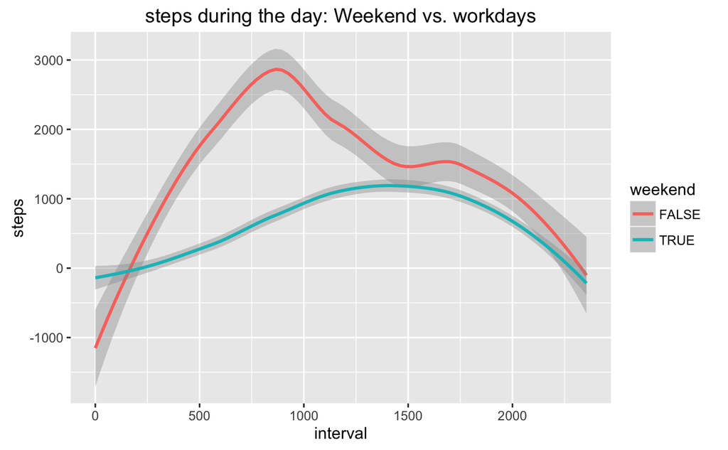

```r
activityByWeekendSum <- aggregate(steps ~ interval + weekend, data=activity, sum)
ggplot(activityByWeekendSum,aes(x = interval, y = steps)) + geom_smooth(aes(col = weekend)) + ggtitle(label="steps during the day: Weekend vs. workdays")
```

### Imputing missing values

1. Calculate and report the total number of missing values in the dataset (i.e. the total number of rows with 𝙽𝙰s)

```r
pMiss <- function(x){sum(is.na(x))/length(x)*100}
apply(activity,2,pMiss)
```

```
   steps     date interval  weekday  weekend
13.11475  0.00000  0.00000  0.00000  0.00000
```

2. Devise a strategy for filling in all of the missing values in the dataset. The strategy does not need to be sophisticated. For example, you could use the mean/median for that day, or the mean for that 5-minute interval, etc.

```r
library(mice)
temp <- mice(data = activity[,c(1,3)], m = 5, method = "pmm", maxit = 10, seed = 500)
completedData <- complete(temp,1)
activity$StepsImputed <- completedData$steps
activity$Imputed <- is.na(activity$steps)
```

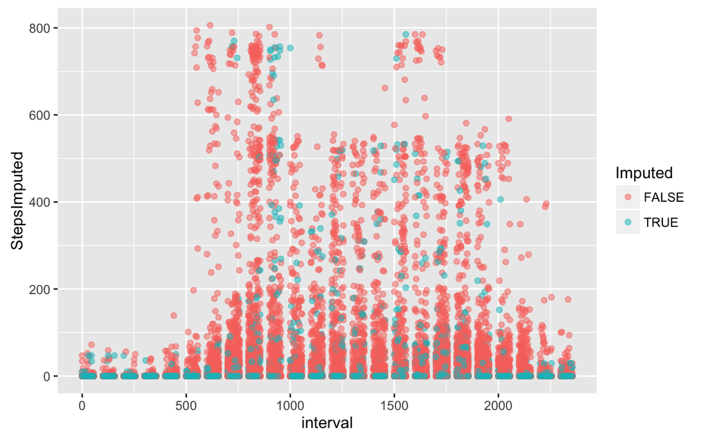

```r
ggplot(activity, aes(x = interval, y =StepsImputed, col = Imputed)) +
    geom_point(alpha = 0.5)
```

3. Create a new dataset that is equal to the original dataset but with the missing data filled in.

4.1 Make a histogram of the total number of steps taken each day

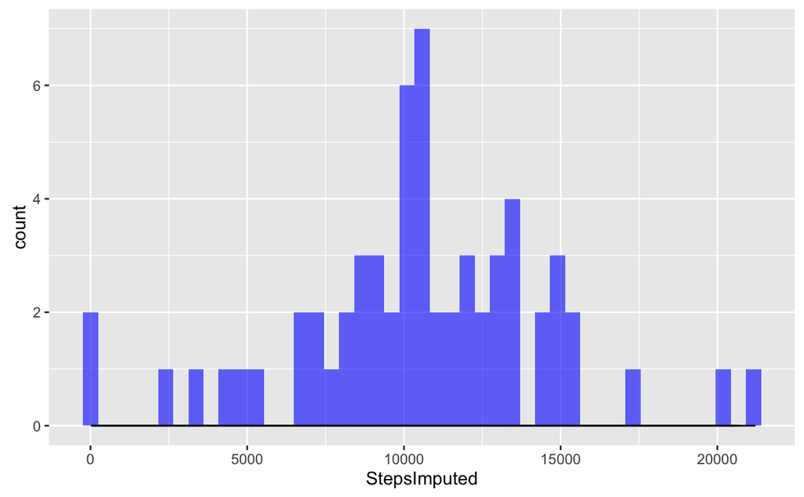

```r
activityByDateSum <- aggregate(StepsImputed~date, activity, sum)
ggplot(activityByDateSum, aes(StepsImputed)) + geom_histogram(bins = 45, alpha = 0.6, fill = "blue") + geom_density()
```

```r
activityByDateSum2 <- aggregate(StepsImputed ~ interval, data=activity, sum)
summary(activityByDateSum2$StepsImputed)
```

```
   Min. 1st Qu.  Median    Mean 3rd Qu.    Max.
    0.0   138.2  2100.0  2230.0  3245.0 11420.0
```

4.3 Do these values differ from the estimates from the first part of the assignment? What is the impact of imputing missing data on the estimates of the total daily number of steps?

Yes. Adding the new values has increased both mean and the median.